# Notebook

## Explaining the Inverse CDF method (by pictures)

In this note, I'll show a pictorial proof of the inverse-cdf method, used to generate samples of any random variable, as long as we know its cdf. I have read many algebraic proofs, but it never clicked until I drew it out.

```python
import numpy as np
import matplotlib.pyplot as plt
import scipy.stats as st
%matplotlib inline
plt.style.use('ggplot')
```

```python
x = np.linspace(6,-6,100)
```

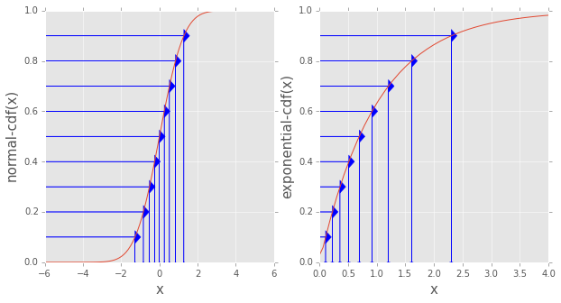

```python
plt.figure(figsize=[10,5])

plt.subplot(121)
rv_norm = st.norm()
plt.plot(x, rv_norm.cdf(x))
for k in np.arange(0, 1, 0.1):
    plt.arrow(-6, k, rv_norm.ppf(k) + 6, 0, ec='b', fc='b', head_width=0.05, head_length=0.3)
    plt.arrow(rv_norm.ppf(k), k, 0, -k, ec='b', fc='b', head_width=0.05, head_length=0.3)
plt.ylabel("normal-cdf(x)", fontsize=15)
plt.xlabel("x", fontsize=15)

plt.subplot(122)
rv_exp = st.expon()
plt.plot(x, rv_exp.cdf(x))
plt.axis([0,4,0,1])
for k in np.arange(0, 1, 0.1):
    plt.arrow(0, k, rv_exp.ppf(k), 0, ec='b', fc='b', head_width=0.05, head_length=0.1)
    plt.arrow(rv_exp.ppf(k), k, 0, -k, ec='b', fc='b', head_width=0.05, head_length=0.1)
plt.ylabel("exponential-cdf(x)", fontsize=15)
plt.xlabel("x", fontsize=15)
```

**Inverse cdf method**

Step 1. Generate a uniform random variable $y$

- I choose a bunch of points on the y-axis that are equally spaced from 0 to 1. These $y_i$'s constitute our sample of a uniform random variable

Step 2. Find $x_i = \text{inverse-cdf}(y_i)$ for each $y_i$

- We find the corresponding $x_i$ for each $y_i$ by drawing an arrow from $y_i$ to the cdf curve, then down to the x-axis
- Notice how $\text{cdf}(x_i) = y_i$ as desired

Following these steps, the $x_i$'s we generated in Step 2 is a sample of a random variable with the plotted cdf.

**Intuition**

Why are the $x_i$'s the sample that we want?

Look at the left panel where the red line is the normal cdf. Even though the $y_i$'s are evenly spaced (i.e. uniformaly distribute), the $x_i$'s are much more closer to one another near mean 0 because the red line (normal cdf) rises much quicker near 0. In other words, we generate $x_i$'s in a way such that we get more $x_i$ where the cdf rises quicker. This makes perfect sense, because between a range $[c_1, c_2]$, the more $x_i$'s there are in that range, the more the cdf increases.